# Law of Large Numbers

Bernard Ade

12-05-2016

The last post I discussed the intuition behind [population & sample](http://knowdata.github.io/blog/content/population_sample.nb.html). In this post I will discuss a popular theory in statistics called Law of Large numbers. Each of these concepts build on knowledge from previous topics.

##### What is the law of large numbers?

The law of large numbers states that when we are measuring some subject of interest as the number of observations gets large, the observed probability approaches the expected probability. The **intuition** here is to be mindful of how the law of large numbers builds confidence on our predictions and deals with randonmess.

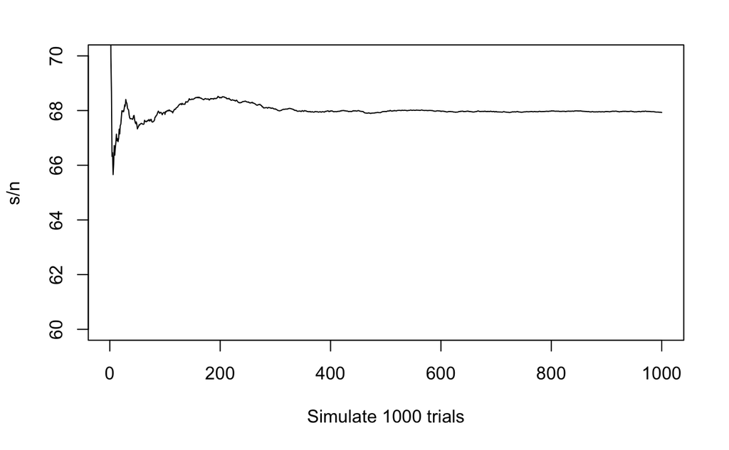

```r
n<-c(1:1000)
x<-rnorm(1000,68,3.5)
s<-cumsum(x)
plot(s/n, xlab="Simulate 1000 trials", ylim=c(60,70), type="l")
```

As we can see in the example above, in the long run, the fluctuations in the trials eventually settled on the true mean.

##### References

[Harvard University - Lecture 29: Law of Large Numbers and Central Limit Theorem | Statistics 110](https://www.youtube.com/watch?v=VpuN8vCQ--M)

[Law of large numbers | Probability and Statistics | Khan Academy](https://www.youtube.com/watch?v=VpuN8vCQ--M&t=5s)